# lab04

Author

Phi Nguyen

Published

April 22, 2026

# 1 Lab 4 Deliverable

## 1.1 Part 1: Tidying

```r
broadband_untidy <- read_excel(here::here("data","gapminder_broadband_per_100.xlsx")) %>% janitor::clean_names()

broadband_tidy <- broadband_untidy %>%
  pivot_longer(x1998:x2011,names_to = "year",values_to = "subscribers_per_100_people")

colnames(broadband_tidy) <- c("country","year","subscribers_per_100_people")
```

## 1.2 Part 2: Gapminder

Recall the Task Menu:

- Get the maximum and minimum of GDP per capita for all continents.
- Look at the spread of GDP per capita across countries within the continents.
- How does life expectancy vary across different continents?
- Report the absolute and/or relative abundance of countries with low life expectancy over time by continent: Compute some measure of worldwide life expectancy - you decide - a mean or median, or some other quantile, or perhaps simply the life expectancy at your current age. Then determine how many countries on each continent have a life expectancy less than this benchmark, for each year.
- Make up your own!

### 1.2.1 Life Expectancy distribution across continets and time

#### 1.2.1.1 Table

```r
part_2_1 <- gapminder %>%
  select(continent,year,lifeExp)

part_2_1
```

```
# A tibble: 1,704 × 3
   continent  year lifeExp
   <fct>     <int>   <dbl>
 1 Asia       1952    28.8
 2 Asia       1957    30.3
 3 Asia       1962    32.0
 4 Asia       1967    34.0
 5 Asia       1972    36.1
 6 Asia       1977    38.4
 7 Asia       1982    39.9
 8 Asia       1987    40.8
 9 Asia       1992    41.7
10 Asia       1997    41.8
# ℹ 1,694 more rows
```

#### 1.2.1.2 Companion Graph

[figure not shown]

```r
  ggplot(part_2_1,aes(x=lifeExp,y=factor(year),fill=factor(continent),alpha=0.5)) +
  geom_density_ridges(aes(scale = 1.3)) +
  scale_fill_viridis_d() +
  guides(alpha="none") +
  labs(x="Life Expectancy",y="Year",fill="Continent",title="Life Expectancy by Continents over Time")
```

#### 1.2.1.3 Description/Writeup

Generating the data for this figure was not difficult, the main thing that I struggled with was getting the ridgeline plot to generate. For the plot to generate correctly the y axis needed to be a factor however the error message didn’t mention that and I didn’t see anything in the documentation either. I was able to solve the issue because someone on stack overflow had run into something similar.

I think this gives a lot of information, we are able to see both the distribution of life expecatancies and how it changes over time.

### 1.2.2 GDP changes across countries within the continents.

#### 1.2.2.1 Table

```r
part_2_2 <- gapminder %>%
  select(continent,country,year,gdpPercap) %>%
  group_by(country,continent) %>%
  filter(year == 1952 | year == 2007) %>%
  pivot_wider(names_from = year,names_prefix = "gdp_",values_from = gdpPercap) %>%
  mutate(gdp_change = gdp_2007 - gdp_1952)


part_2_2
```

```
# A tibble: 142 × 5
# Groups:   country, continent [142]
   continent country     gdp_1952 gdp_2007 gdp_change
   <fct>     <fct>          <dbl>    <dbl>      <dbl>
 1 Asia      Afghanistan     779.     975.       195.
 2 Europe    Albania        1601.    5937.      4336.
 3 Africa    Algeria        2449.    6223.      3774.
 4 Africa    Angola         3521.    4797.      1277.
 5 Americas  Argentina      5911.   12779.      6868.
 6 Oceania   Australia     10040.   34435.     24396.
 7 Europe    Austria        6137.   36126.     29989.
 8 Asia      Bahrain        9867.   29796.     19929.
 9 Asia      Bangladesh      684.    1391.       707.
10 Europe    Belgium        8343.   33693.     25349.
# ℹ 132 more rows
```

#### 1.2.2.2 Companion Graph

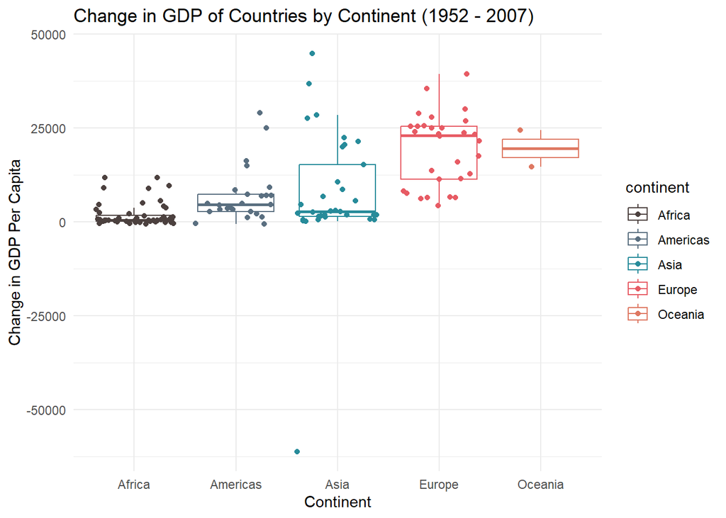

```r
ggplot(part_2_2,aes(x=continent,y=gdp_change,colour = continent)) +
  geom_boxplot(outlier.shape=NA) +
  geom_jitter() +
  labs(x="Continent",y="Change in GDP Per Capita",title = "Change in GDP of Countries by Continent (1952 - 2007)") +
  theme_minimal() +
  scale_colour_ghibli_d("PonyoMedium")
```